# Data Science Tutorial

## Introduction

Welcome to our data science tutorial. This tutorial will lead you through in developing and predicting a machine learning model based on NBA player stats data set. It will go through the concept of importing, cleaning, visualizing, model selection, implementation and results.

### Libraries used

```python
import pandas as pd
import matplotlib.pyplot as plt
import seaborn as sns
import scipy.stats as stats
import numpy as np
from sklearn import metrics
from sklearn.preprocessing import StandardScaler
from sklearn.cluster import KMeans
import warnings
warnings.filterwarnings("ignore")
pd.get_option("display.max_columns",None)
```

```
20
```

### Important Libraries

##### Pandas

# Importing Data

After importing the required libaries, next step is to import the dataset and display. For this purpose we are going to import dataset with the help of read_csv() function. This function is used to import any file with delimiters. Code for this purpose is listed below:

```python
data = pd.read_csv("data.csv")
data.head()
```

|  | RANK | FULL NAME | TEAM | POS | AGE | GP | MPG | MinutesPercentage | USG%Usage Rate | TO%Turnover Rate | ... | RPGRebounds | TRB%Total Rebound Percentage | APGAssistsAssists per game. | AST%Assist Percentage | SPGSteals | BPGBlocks | TOPGTurnovers | VIVersatility IndexVersatility index | ORTGOffensive RatingIndividual | DRTGDefensive RatingIndividual |
| --- | --- | --- | --- | --- | --- | --- | --- | --- | --- | --- | --- | --- | --- | --- | --- | --- | --- | --- | --- | --- | --- |
| 0 | 1 | Nicolas Batum | Lac | G-F | 32.54 | 18 | 29.7 | 61.9 | 10.3 | 5.1 | ... | 5.6 | 10.9 | 2.1 | 9.5 | 1.33 | 0.56 | 0.33 | 6.1 | 139.1 | 108.5 |
| 1 | 2 | Paul George | Lac | F | 31.16 | 18 | 40.9 | 85.1 | 30.8 | 13.0 | ... | 9.7 | 13.7 | 5.6 | 22.5 | 1.06 | 0.50 | 3.50 | 11.1 | 112.8 | 104.7 |
| 2 | 3 | Reggie Jackson | Lac | G | 31.20 | 18 | 32.5 | 67.7 | 22.7 | 9.8 | ... | 3.1 | 5.5 | 3.2 | 15.7 | 0.89 | 0.17 | 1.56 | 6.9 | 121.3 | 108.1 |
| 3 | 4 | Terance Mann | Lac | G-F | 24.69 | 18 | 19.4 | 40.3 | 14.9 | 2.7 | ... | 2.7 | 8.1 | 0.8 | 6.0 | 0.56 | 0.28 | 0.17 | 5.3 | 135.5 | 104.2 |
| 4 | 5 | Marcus Morris Sr. | Lac | F | 31.82 | 18 | 31.2 | 65.0 | 16.7 | 3.5 | ... | 4.0 | 7.4 | 1.5 | 7.0 | 0.56 | 0.50 | 0.39 | 5.2 | 113.5 | 107.7 |

5 rows × 29 columns

> We have total 29 columns in which we have three categorical variables that includes fullname, team and POS.

# Data Representation

First we will define the header with 0 index as our column names are found at 0 index, then by using the function iloc() and by using columns we will make that header as column names and then drop the header row at 0th index. Code for this purpose is:

```python
#data cleaning and managing
#header = 0
#data.columns = data.iloc[header]
#data = data.drop(header)
#data.head(3)
```

The data is succesfully updated and now it is ready to go for further stages, before proceeding further we want to know about it's data types and info about the dataset.

### Data Types

```python
data.dtypes
```

```
RANK                                      int64
FULL NAME                                object
TEAM                                     object
POS                                      object
AGE                                     float64
GP                                        int64
MPG                                     float64
MinutesPercentage                       float64
USG%Usage Rate                          float64
TO%Turnover Rate                        float64
FTA                                       int64
FT%                                     float64
2PA                                       int64
2P%                                     float64
3PA                                       int64
3P%                                     float64
eFG%Effective Shooting Percentage       float64
TS%True Shooting Percentage             float64
PPGPoints                               float64
RPGRebounds                             float64
TRB%Total Rebound Percentage            float64
APGAssistsAssists per game.             float64
AST%Assist Percentage                   float64
SPGSteals                               float64
BPGBlocks                               float64
TOPGTurnovers                           float64
VIVersatility IndexVersatility index    float64
ORTGOffensive RatingIndividual          float64
DRTGDefensive RatingIndividual          float64
dtype: object
```

```python
data.shape
```

```
(238, 29)
```

### Describe

Pandas describe is used to view some basic statistics of the dataset which includes the mean, median, std, count etc.

```python
data.describe()
```

|  | RANK | AGE | GP | MPG | MinutesPercentage | USG%Usage Rate | TO%Turnover Rate | FTA | FT% | 2PA | ... | RPGRebounds | TRB%Total Rebound Percentage | APGAssistsAssists per game. | AST%Assist Percentage | SPGSteals | BPGBlocks | TOPGTurnovers | VIVersatility IndexVersatility index | ORTGOffensive RatingIndividual | DRTGDefensive RatingIndividual |
| --- | --- | --- | --- | --- | --- | --- | --- | --- | --- | --- | --- | --- | --- | --- | --- | --- | --- | --- | --- | --- | --- |
| count | 238.000000 | 238.000000 | 238.000000 | 238.000000 | 238.000000 | 238.000000 | 230.000000 | 238.000000 | 238.000000 | 238.000000 | ... | 238.000000 | 238.000000 | 238.000000 | 238.000000 | 238.000000 | 238.000000 | 238.000000 | 238.000000 | 195.000000 | 196.000000 |
| mean | 119.500000 | 27.343109 | 6.957983 | 18.184874 | 37.873529 | 18.168067 | 10.436957 | 14.176471 | 0.577908 | 32.911765 | ... | 3.282353 | 10.584874 | 1.622269 | 11.341176 | 0.482269 | 0.353487 | 0.878908 | 5.352521 | 108.549744 | 105.201020 |
| std | 68.848868 | 4.293080 | 4.403480 | 12.688036 | 26.441154 | 8.578134 | 9.849908 | 22.849405 | 0.374235 | 45.222336 | ... | 2.879863 | 8.013540 | 2.174063 | 11.280886 | 0.477800 | 0.441307 | 1.008703 | 3.618712 | 26.873916 | 6.415206 |
| min | 1.000000 | 20.000000 | 1.000000 | 0.900000 | 1.900000 | 0.000000 | 0.000000 | 0.000000 | 0.000000 | 0.000000 | ... | 0.000000 | 0.000000 | 0.000000 | 0.000000 | 0.000000 | 0.000000 | 0.000000 | 0.000000 | 0.000000 | 80.700000 |
| 25% | 60.250000 | 23.832500 | 4.000000 | 5.925000 | 12.350000 | 12.400000 | 4.000000 | 1.000000 | 0.000000 | 4.000000 | ... | 1.000000 | 6.025000 | 0.300000 | 3.600000 | 0.000000 | 0.000000 | 0.170000 | 3.125000 | 99.350000 | 101.200000 |
| 50% | 119.500000 | 27.155000 | 5.000000 | 16.500000 | 34.350000 | 17.000000 | 9.500000 | 5.500000 | 0.725500 | 15.000000 | ... | 2.600000 | 8.850000 | 0.800000 | 8.300000 | 0.330000 | 0.200000 | 0.565000 | 5.650000 | 112.200000 | 105.650000 |
| 75% | 178.750000 | 30.297500 | 10.000000 | 29.850000 | 62.125000 | 22.450000 | 13.900000 | 16.000000 | 0.870250 | 42.750000 | ... | 4.500000 | 13.700000 | 2.075000 | 16.425000 | 0.800000 | 0.500000 | 1.200000 | 7.500000 | 121.950000 | 108.825000 |
| max | 238.000000 | 37.420000 | 18.000000 | 41.300000 | 86.100000 | 52.500000 | 75.000000 | 145.000000 | 1.000000 | 252.000000 | ... | 13.000000 | 64.100000 | 11.800000 | 54.000000 | 2.800000 | 3.000000 | 4.600000 | 14.400000 | 183.300000 | 123.500000 |

8 rows × 26 columns

```python
data.info()
```

```
<class 'pandas.core.frame.DataFrame'>
RangeIndex: 238 entries, 0 to 237
Data columns (total 29 columns):
 #   Column                                Non-Null Count  Dtype
---  ------                                --------------  -----
 0   RANK                                  238 non-null    int64
 1   FULL NAME                             238 non-null    object
 2   TEAM                                  238 non-null    object
 3   POS                                   238 non-null    object
 4   AGE                                   238 non-null    float64
 5   GP                                    238 non-null    int64
 6   MPG                                   238 non-null    float64
 7   MinutesPercentage                     238 non-null    float64
 8   USG%Usage Rate                        238 non-null    float64
 9   TO%Turnover Rate                      230 non-null    float64
```

[output cut: 21 more lines]

## Exploratory data analysis

- Getting some descriptive analysis of the dataset which includes, finding missing or null values, duplicate values.
- Dealing with the null values
- Univariate and bivariate analysis of the dataset.
- Splitting the data into x and y for data modeling and predictive analysis

#### Null values

Finding the total null values of the all columns in the dataset using the function isnull() and sum()

```python
data.isnull().sum()
```

```
RANK                                     0
FULL NAME                                0
TEAM                                     0
POS                                      0
AGE                                      0
GP                                       0
MPG                                      0
MinutesPercentage                        0
USG%Usage Rate                           0
TO%Turnover Rate                         8
FTA                                      0
FT%                                      0
2PA                                      0
2P%                                      0
3PA                                      0
3P%                                      0
eFG%Effective Shooting Percentage       10
TS%True Shooting Percentage              8
PPGPoints                                0
RPGRebounds                              0
TRB%Total Rebound Percentage             0
APGAssistsAssists per game.              0
AST%Assist Percentage                    0
SPGSteals                                0
BPGBlocks                                0
TOPGTurnovers                            0
VIVersatility IndexVersatility index     0
ORTGOffensive RatingIndividual          43
DRTGDefensive RatingIndividual          42
dtype: int64
```

#### Dropping Null values

Null values can be drop with the help of function dropna().

```python
data = data.dropna()
data.isnull().sum()
```

```
RANK                                    0
FULL NAME                               0
TEAM                                    0
POS                                     0
AGE                                     0
GP                                      0
MPG                                     0
MinutesPercentage                       0
USG%Usage Rate                          0
TO%Turnover Rate                        0
FTA                                     0
FT%                                     0
2PA                                     0
2P%                                     0
3PA                                     0
3P%                                     0
eFG%Effective Shooting Percentage       0
TS%True Shooting Percentage             0
PPGPoints                               0
RPGRebounds                             0
TRB%Total Rebound Percentage            0
APGAssistsAssists per game.             0
AST%Assist Percentage                   0
SPGSteals                               0
BPGBlocks                               0
TOPGTurnovers                           0
VIVersatility IndexVersatility index    0
ORTGOffensive RatingIndividual          0
DRTGDefensive RatingIndividual          0
dtype: int64
```

From the results it is cleared that we don't have any null values inside our dataset. We will check it thorugh the shape of the dataset.

```python
data.shape
```

```
(195, 29)
```

```python
#counting the duplicates
data.duplicated().sum()
```

```
0
```

```python
# extracting the duplicates
#print(data[data.duplicated()])
df =data.drop(['TEAM','FULL NAME','POS'],axis =1)
df.head(2)
```

|  | RANK | AGE | GP | MPG | MinutesPercentage | USG%Usage Rate | TO%Turnover Rate | FTA | FT% | 2PA | ... | RPGRebounds | TRB%Total Rebound Percentage | APGAssistsAssists per game. | AST%Assist Percentage | SPGSteals | BPGBlocks | TOPGTurnovers | VIVersatility IndexVersatility index | ORTGOffensive RatingIndividual | DRTGDefensive RatingIndividual |
| --- | --- | --- | --- | --- | --- | --- | --- | --- | --- | --- | --- | --- | --- | --- | --- | --- | --- | --- | --- | --- | --- |
| 0 | 1 | 32.54 | 18 | 29.7 | 61.9 | 10.3 | 5.1 | 21 | 0.810 | 34 | ... | 5.6 | 10.9 | 2.1 | 9.5 | 1.33 | 0.56 | 0.33 | 6.1 | 139.1 | 108.5 |
| 1 | 2 | 31.16 | 18 | 40.9 | 85.1 | 30.8 | 13.0 | 145 | 0.841 | 213 | ... | 9.7 | 13.7 | 5.6 | 22.5 | 1.06 | 0.50 | 3.50 | 11.1 | 112.8 | 104.7 |

2 rows × 26 columns

```python
df = df.apply(pd.to_numeric, errors='coerce')
df.dtypes
```

```
RANK                                      int64
AGE                                     float64
GP                                        int64
MPG                                     float64
MinutesPercentage                       float64
USG%Usage Rate                          float64
TO%Turnover Rate                        float64
FTA                                       int64
FT%                                     float64
2PA                                       int64
2P%                                     float64
3PA                                       int64
3P%                                     float64
eFG%Effective Shooting Percentage       float64
TS%True Shooting Percentage             float64
PPGPoints                               float64
RPGRebounds                             float64
TRB%Total Rebound Percentage            float64
APGAssistsAssists per game.             float64
AST%Assist Percentage                   float64
SPGSteals                               float64
BPGBlocks                               float64
TOPGTurnovers                           float64
VIVersatility IndexVersatility index    float64
ORTGOffensive RatingIndividual          float64
DRTGDefensive RatingIndividual          float64
dtype: object
```

- After droping the categorical variables and applying to_numeric paramter to convert our data types to numeric variables the output is shown above.
- Next Important step is to visualize the data to get some meaningful information from the data. For this purpose we are going to do univariate and bivariate analysis

#### Univariate Analysis

Univariate analysis is the most fundamental type of data analysis. Uni signifies "one," implying that the data contains only one type of variable. The primary goal of univariate analysis is to characterise the data. The data will be gathered, summarised, and a pattern will be discovered. Univariate analysis can be done in a variety of ways, the majority of which are descriptive in nature. These ways are Histograms, Bar Charts, Pie Charts, The Frequency Distribution Tables, Frequency Polygons.

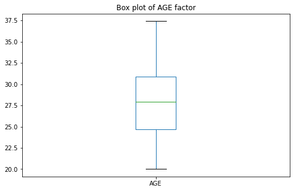

```python
# Univariate Analysis
plt.figure(figsize=(8, 5))
df['AGE'].plot.box()
plt.title("Box plot of AGE factor")
plt.show()
```

Form the boxplot of Age column, we have seen that our data mostly found between 22 and 32 and no outlier is found.

- We want to see the distribution of the teams in the dataset. For this purpose we are going to make barchart distribution of the values.

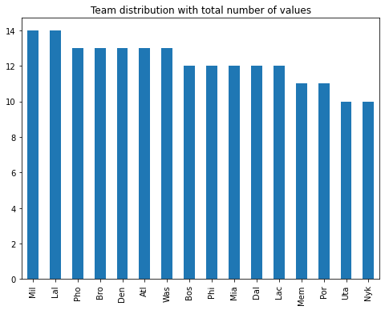

```python
fig = plt.figure(figsize =(8, 6))
data['TEAM'].value_counts().plot(kind='bar')
plt.title("Team distribution with total number of values")
```

### Bivariate analysis

Bivariate analysis is is carried out to determine the relationship among the variables in the dataset and the target dependent variable to determine the relationship between two variables.

In the first analysis of two variables we are going to deal with the age and GP factor and plot the distribution of these two variables using scatter plot.

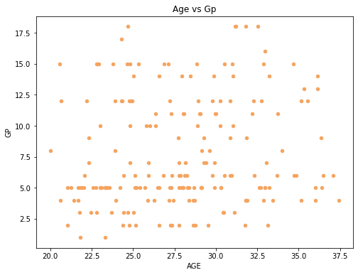

```python
#Bivariate analysis
df.plot.scatter(x = 'AGE', y = 'GP',
                  color = 'sandybrown', title = 'Age vs Gp',figsize=(8,6))
```

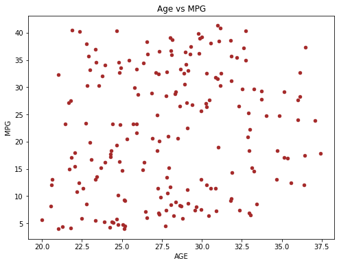

```python
df.plot.scatter(x = 'AGE', y = 'MPG',
                  color = 'brown', title = 'Age vs MPG',figsize=(8,6))
```

The intensity and direction of the linear (straight-line) relationship between two quantitative variables is summarised by correlation. It takes values between -1 and +1 and is denoted by the letter r. A positive r value implies a positive relationship, while a negative r value suggests a negative relationship.

```python
corr=df.corr(method ='pearson')
```

```
[Text(0.5, 0, 'RANK'),
```

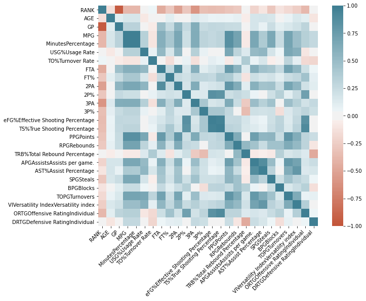

```python
plt.figure(figsize = (10,8))
ax = sns.heatmap(
    corr,
    vmin=-1, vmax=1, center=0,
    cmap=sns.diverging_palette(20, 220, n=200),
    square=True
)
ax.set_xticklabels(
    ax.get_xticklabels(),
    rotation=45,
    horizontalalignment='right'
)
```

```
[Text(0, 0.5, 'RANK'),
```

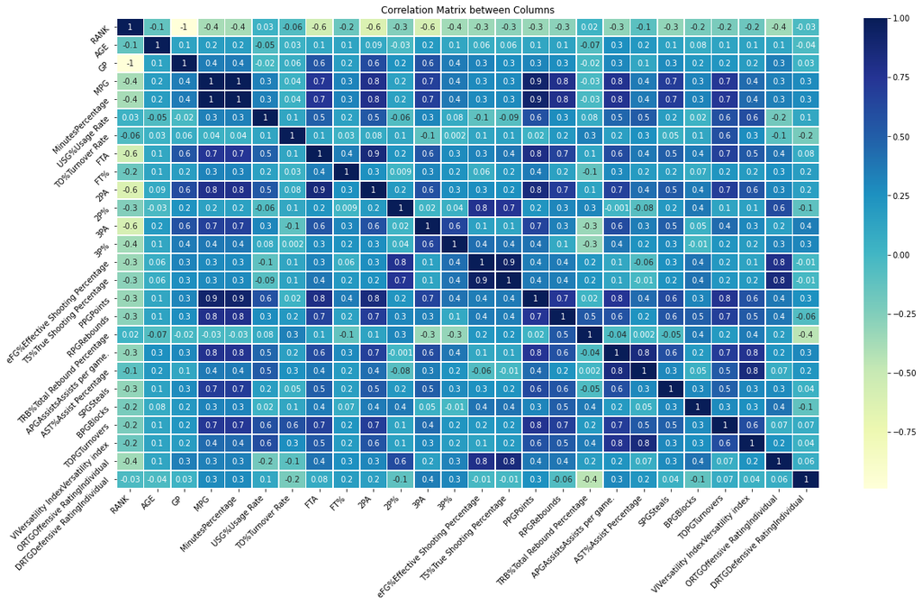

```python
#Correlation Matrix
plt.subplots(figsize = (20,11))
g = sns.heatmap(df.corr("spearman"), annot = True, cmap = "YlGnBu", fmt = '.1g', linewidths=.5,)

g.set_title("Correlation Matrix between Columns")
g.set_xticklabels(g.get_xticklabels(), rotation=45, horizontalalignment='right')
g.set_yticklabels(g.get_yticklabels(), rotation=45, horizontalalignment='right')
```

> In our heat map we have find the correlation among different important features of the dataset.We can say that minutespercentage is having a good correlation with FTA

## Hypothesis testing

Hypothesis testing is a statistical strategy for making statistical conclusions based on data from experiments. Hypothesis testing is essentially making an assumption about a parameter. A hypothesis test compares necessarily related distinct assumptions about a group to see which one the sample data best supports. A hypothesis test is used to determine whether a result is statistically significant. The null hypothesis is a general definition or baseline assumption in hypothesis testing that there is no relationship between two measurable events or no connection among categories. To put it another way, it's a fundamental assumption based on domain or problem information.  
The alternative hypothesis is a hypothesis that opposes the null hypothesis and is used in hypothesis testing. The observations are usually assumed to be the consequence of a true effect with some random fluctuation superposed.

### Paired sampled t-test

The dependent sample t-test is another name for the paired sample t-test. It's only one experiment that looks for a statistically significant difference between two related variables.  
We are going to perform paired sample t-test on our dataset which includes 2PA and 3PA columns.

```python
test,p_Val = stats.ttest_rel(df['2PA'], df['3PA'])
print(p_Val)
if p_Val<0.05:
    print("We Reject null hypothesis")
else:
    print("accept null hypothesis")
```

```
6.261831927615957e-07
We Reject null hypothesis
```

From the results we have found that our p value is lesser than 0.05 and we reject the null hypothesis. The next step will be implementing the machine learning and making predicitions about the data.

## Machine Learning

#### Advancing K-means cluster into our dataset

The three types of learning in Machine Learning can be broadly characterised as follows: Supervised learning, unsupervised learning, and semi-supervised learning are the three types of learning. Unsupervised Learning algorithms do not have any variables to predict that are related to the data. Rather than just an outcome, the data has only an intake, which is a set of numerous variables that characterise the data.  
Clustering is the challenge of arranging a collection of objects so that objects in the same group are more similar than objects in other groups. Correlation is an indicator that shows how closely two data objects are related. Clustering is mostly employed in exploratory data analysis.  
Machine learning, problem solving, computer vision, data mining, informatics, image segmentation, and image processing are just a few of the domains where it's used.  
K-Means is a type of centroid-based clustering algorithm. A centroid is a data point in the centre of a cluster (imaginary or actual). Clusters are represented by a central vector or a centroid in centroid-based clustering. This centroid may or may not be a part of the dataset. K - means clustering is an adaptive technique that determines similarity by how close a data point is to the cluster's centroid.  
You use the distance measurement function (also known as the similarity measurement function) to measure the distances:  
$ d=\left | x2 - x1 \right | + \left | y2 - y1 \right |+ \left | z2-z1 \right |\ $

```python
kmeans = KMeans(n_clusters=2)
kmeans.fit(df.drop('MinutesPercentage',axis=1))
```

```
KMeans(n_clusters=2)
```

In the above code of lines we are actually proceeding only with the numercial values of the dataset, not reading the categorical values.  
To train our model we are droping our target variable that is MinutesPercentage and training on the remaining features of the dataset. You can also use some of the imporatn features of the dataset for this prupose.

Next we are going to print the cluster centers of our training data.

```python
Centers=kmeans.cluster_centers_
print(Centers)
```

```
[[150.16071429  27.489375     4.58928571  17.73303571  17.84017857
   11.49910714   7.42857143   0.60973214  17.79464286   0.45279464
   10.42857143   0.2379375    0.46491964   0.49955357   7.09107143
    3.22767857  10.2875       1.34821429  10.27857143   0.47053571
    0.36089286   0.82151786   5.35803571 102.17946429 104.63571429]
 [ 43.80722892  28.6139759   12.01204819  26.88433735  19.68433735
   10.13373494  30.25301205   0.7500241   69.57831325   0.5309759
   47.80722892   0.33049398   0.54680723   0.57620482  13.24698795
    4.77590361   9.95662651   2.74698795  14.48915663   0.72843373
    0.47915663   1.34325301   7.18554217 117.14578313 105.74337349]]
```

Wow!!! Interesting, we have found no negative values from our clusters.

Next important step is to convert and scale the cluster centers into clusters by converting them. This will help us to examine the accuracy and graphical representation of the model.

```python
def converter(Centers):
    if Centers=='Yes':
        return 1
    else:
        return 0
df['Cluster'] = df['MinutesPercentage'].apply(converter)
df.head(1)
```

|  | RANK | AGE | GP | MPG | MinutesPercentage | USG%Usage Rate | TO%Turnover Rate | FTA | FT% | 2PA | ... | TRB%Total Rebound Percentage | APGAssistsAssists per game. | AST%Assist Percentage | SPGSteals | BPGBlocks | TOPGTurnovers | VIVersatility IndexVersatility index | ORTGOffensive RatingIndividual | DRTGDefensive RatingIndividual | Cluster |
| --- | --- | --- | --- | --- | --- | --- | --- | --- | --- | --- | --- | --- | --- | --- | --- | --- | --- | --- | --- | --- | --- |
| 0 | 1 | 32.54 | 18 | 29.7 | 61.9 | 10.3 | 5.1 | 21 | 0.81 | 34 | ... | 10.9 | 2.1 | 9.5 | 1.33 | 0.56 | 0.33 | 6.1 | 139.1 | 108.5 | 0 |

1 rows × 27 columns

We have to convert our target variable into some form of values for comparison with predicted values and models output because we don't have any kind of labels for that purpose so it's difficult to evaluate the clustering algorithm that don't have labels.

```python
df.MinutesPercentage.value_counts()
```

```
68.2    3
17.6    3
48.5    2
63.2    2
69.4    2
       ..
41.3    1
21.8    1
10.7    1
31.6    1
65.0    1
Name: MinutesPercentage, Length: 170, dtype: int64
```

Important predictive analytics such as recall, specificity, accuracy, and precision are visualised using confusion matrices. Confusion matrices are important because they allow you to compare values such as True Positives, False Positives, True Negatives, and False Negatives in a straightforward manner.  
Other machine learning classification measures, such as "Accuracy," on the other hand, provide less valuable data because Accuracy is simply the difference between correct and incorrect predictions divided by the total number of predictions.

```python
from sklearn.metrics import confusion_matrix,classification_report
cf =confusion_matrix(df['Cluster'],kmeans.labels_)
print("ConfusionMatrix",cf)
print(classification_report(df['Cluster'],kmeans.labels_))
```

```
ConfusionMatrix [[112  83]
 [  0   0]]
              precision    recall  f1-score   support

           0       1.00      0.57      0.73       195
           1       0.00      0.00      0.00         0

    accuracy                           0.57       195
   macro avg       0.50      0.29      0.36       195
weighted avg       1.00      0.57      0.73       195
```

- Precision Precision is interested in how many genuinely positive cases your model detected out of all the positive examples it tagged. It's the number of genuine positives divided by total of positive class + false positives.
- Recall The percentage of positive examples that your model was able to recognise from the whole set of positive examples is known as recall. The hit rate is also known as recall, while tolerance refers to a model's genuine positive modeling level or recall chance.

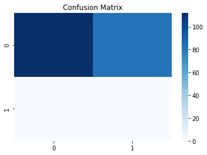

```python
g = sns.heatmap(cf, fmt='', cmap='Blues');
g.set_title("Confusion Matrix")
```

```python
Center1=kmeans.cluster_centers_
print(Center1)
```

```
[[150.16071429  27.489375     4.58928571  17.73303571  17.84017857
   11.49910714   7.42857143   0.60973214  17.79464286   0.45279464
   10.42857143   0.2379375    0.46491964   0.49955357   7.09107143
    3.22767857  10.2875       1.34821429  10.27857143   0.47053571
    0.36089286   0.82151786   5.35803571 102.17946429 104.63571429]
 [ 43.80722892  28.6139759   12.01204819  26.88433735  19.68433735
   10.13373494  30.25301205   0.7500241   69.57831325   0.5309759
   47.80722892   0.33049398   0.54680723   0.57620482  13.24698795
    4.77590361   9.95662651   2.74698795  14.48915663   0.72843373
    0.47915663   1.34325301   7.18554217 117.14578313 105.74337349]]
```

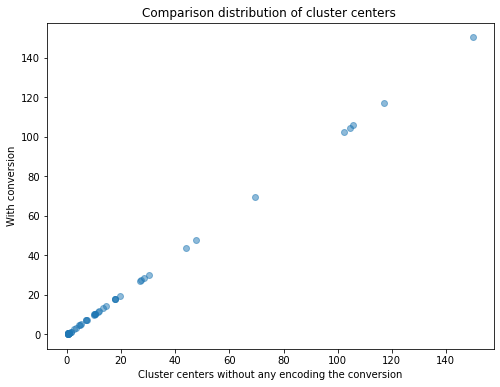

```python
fig = plt.figure(figsize=(8,6))
plt.scatter(Centers,Center1, alpha=0.5)
plt.title('Comparison distribution of cluster centers ')
plt.xlabel('Cluster centers without any encoding the conversion')
plt.ylabel('With conversion')
plt.show()
```

> From the above graph it is clearly shown that the output looks like a linear graph with more distribution between lower values.

Plotting 3d graph for more visualization of the data

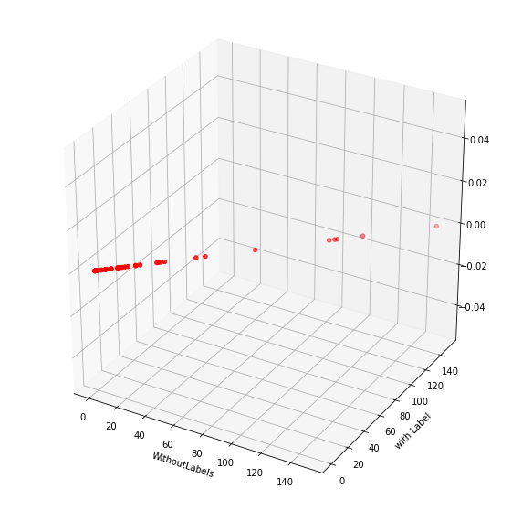

```python
from mpl_toolkits.mplot3d import Axes3D
import matplotlib.pyplot as plt
fig = plt.figure(figsize=(10,10))
ax = fig.add_subplot(111, projection='3d')
x =Centers
y =Center1
ax.scatter(x, y, c='r', marker='o')
ax.set_xlabel('WithoutLabels')
ax.set_ylabel('with Label')
```

Now we want to see the model's output with more number of clusters so we are increasing the number of clusters to 4. Let see how our model is going to give the confusion matrix and classification report.

```python
kmeans = KMeans(n_clusters=4)
kmeans.fit(df.drop('MinutesPercentage',axis=1))
kmeans.cluster_centers_
```

```
array([[1.96650000e+02, 2.72317500e+01, 2.95000000e+00, 1.24475000e+01,
        1.86425000e+01, 1.21075000e+01, 3.07500000e+00, 4.68075000e-01,
        8.15000000e+00, 3.78825000e-01, 5.55000000e+00, 1.44125000e-01,
        3.69175000e-01, 4.09875000e-01, 4.48500000e+00, 2.34500000e+00,
        1.05025000e+01, 7.45000000e-01, 8.22000000e+00, 3.06000000e-01,
        3.29000000e-01, 5.97500000e-01, 4.35750000e+00, 8.58475000e+01,
        1.04982500e+02, 0.00000000e+00],
       [4.01166667e+01, 2.86536667e+01, 1.24000000e+01, 2.33983333e+01,
        1.65916667e+01, 9.70500000e+00, 1.94333333e+01, 7.30500000e-01,
        4.53833333e+01, 5.34200000e-01, 4.13000000e+01, 3.24766667e-01,
        5.48733333e-01, 5.74150000e-01, 9.38166667e+00, 3.93000000e+00,
        9.64833333e+00, 1.86000000e+00, 1.07850000e+01, 6.16833333e-01,
        4.61333333e-01, 8.50833333e-01, 6.18833333e+00, 1.17673333e+02,
        1.05141667e+02, 0.00000000e+00],
       [3.53750000e+01, 2.80537500e+01, 1.30625000e+01, 3.71000000e+01,
        2.97812500e+01, 1.11437500e+01, 7.62500000e+01, 7.98250000e-01,
        1.68062500e+02, 5.42562500e-01, 7.83750000e+01, 3.33875000e-01,
        5.48937500e-01, 5.91375000e-01, 2.59937500e+01, 7.69375000e+00,
        1.14812500e+01, 5.46250000e+00, 2.54562500e+01, 1.13875000e+00,
        5.61875000e-01, 2.82687500e+00, 1.04562500e+01, 1.16775000e+02,
        1.06250000e+02, 0.00000000e+00],
       [1.21708861e+02, 2.78027848e+01, 5.56962025e+00, 2.17987342e+01,
        1.79012658e+01, 1.11911392e+01, 1.05569620e+01, 6.98949367e-01,
        2.56962025e+01, 4.92379747e-01, 1.49620253e+01, 2.97303797e-01,
        5.18759494e-01, 5.50240506e-01, 9.31012658e+00, 3.86329114e+00,
        1.00746835e+01, 1.90126582e+00, 1.22860759e+01, 5.78354430e-01,
        3.84303797e-01, 1.05468354e+00, 6.12151899e+00, 1.11449367e+02,
        1.04912658e+02, 0.00000000e+00]])
```

```python
from sklearn.metrics import confusion_matrix,classification_report
print(confusion_matrix(df['Cluster'],kmeans.labels_))
print(classification_report(df['Cluster'],kmeans.labels_))
```

```
[[40 60 16 79]
 [ 0  0  0  0]
 [ 0  0  0  0]
 [ 0  0  0  0]]
              precision    recall  f1-score   support

           0       1.00      0.21      0.34       195
           1       0.00      0.00      0.00         0
           2       0.00      0.00      0.00         0
           3       0.00      0.00      0.00         0

    accuracy                           0.21       195
   macro avg       0.25      0.05      0.09       195
weighted avg       1.00      0.21      0.34       195
```

The elbow approach is a heuristic used in cluster analysis to determine the number of clusters in a data set. Selecting the elbow of the curve as the number of clusters to utilise and plotting the explained variation as a function of the number of clusters is what this approach does.

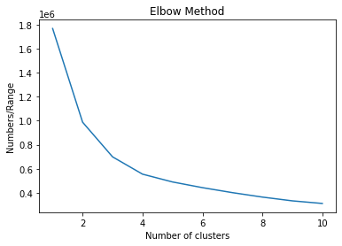

```python
m = []
for i in range(1, 11):
    kmeans = KMeans(n_clusters=i, init='k-means++', max_iter=300, n_init=10, random_state=0)
    kmeans.fit(df.drop('MinutesPercentage',axis=1))
    m.append(kmeans.inertia_)
plt.plot(range(1, 11), m)
plt.title('Elbow Method')
plt.xlabel('Number of clusters')
plt.ylabel('Numbers/Range')
plt.show()
```

> Mostly the number of clusters lies for having higher values of the inertia